# Regression analysis of the IODS project

*This section describes the steps taken to perform regression analysis of data obtained for this IODS project.*

First, let me begin by reading the data for this analysis into R from my local computer. *Please note that the data here was pre-processed through Wrangling from the Helsinki Open data science project, which originally can be found in this link http://www.helsinki.fi/~kvehkala/JYTmooc/JYTOPKYS3-data.txt*

```r
# install.packages("ggplot2")
library(ggplot2)
# Reading the data from my local computer
data <- read.csv("C:\\Users\\fridaya\\Documents\\IODS-project\\data\\learning2014.csv")
learning2014 <- data
```

Now that we have successfully loaded the data to R, we would like to explore the structure and dimension of the data

```r
# Here we are checking the structure of the data learning2014
str(learning2014)
```

```
## 'data.frame':    166 obs. of  7 variables:
##  $ gender  : chr  "F" "M" "F" "M" ...
##  $ age     : int  53 55 49 53 49 38 50 37 37 42 ...
##  $ attitude: num  3.7 3.1 2.5 3.5 3.7 3.8 3.5 2.9 3.8 2.1 ...
##  $ deep    : num  3.58 2.92 3.5 3.5 3.67 ...
##  $ stra    : num  3.38 2.75 3.62 3.12 3.62 ...
##  $ surf    : num  2.58 3.17 2.25 2.25 2.83 ...
##  $ points  : int  25 12 24 10 22 21 21 31 24 26 ...
```

```r
# Here we are checking the dimension of the data learning2014
dim(learning2014)
```

```
## [1] 166   7
```

Now we would like to show the graphical overview of the data

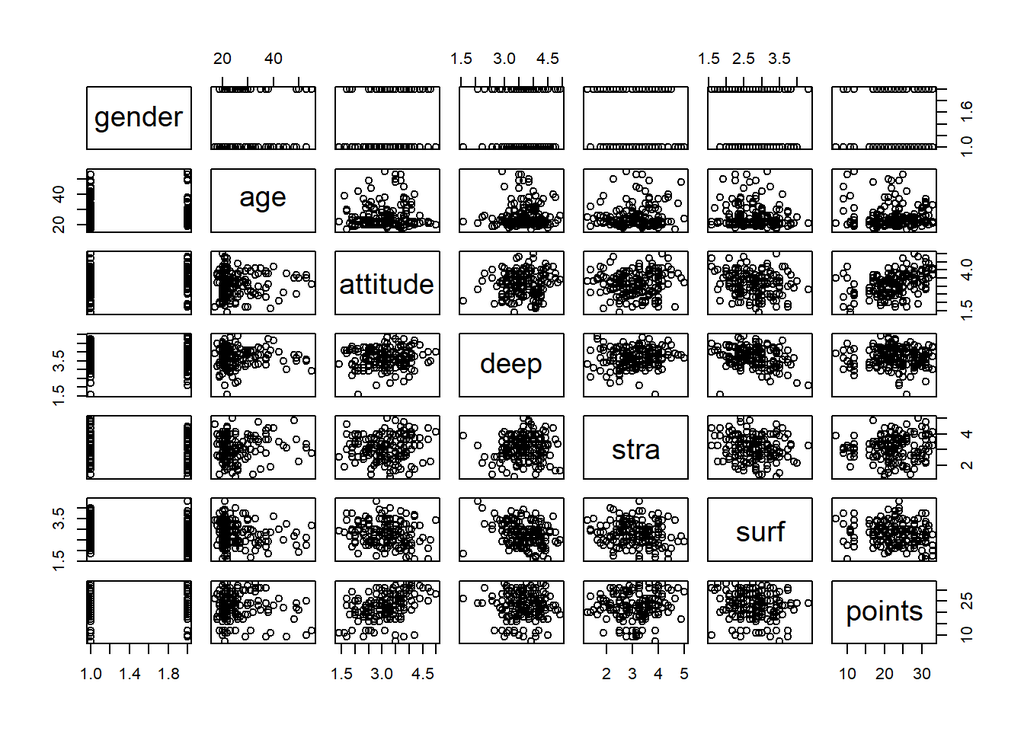

```r
# Here, we try to show the graphical entire overview of the data using plot

plot(learning2014)
```

Figure 1

In Figure 1 above, we see the overview of the variables (gender, age, attitude, deep, stra, surf, and points) in the learning2014 data frame.

*Note* that the variable “gender” scattered plot is not consistent with the other variables. This could be becuase the gender variable did not contain numeric values.

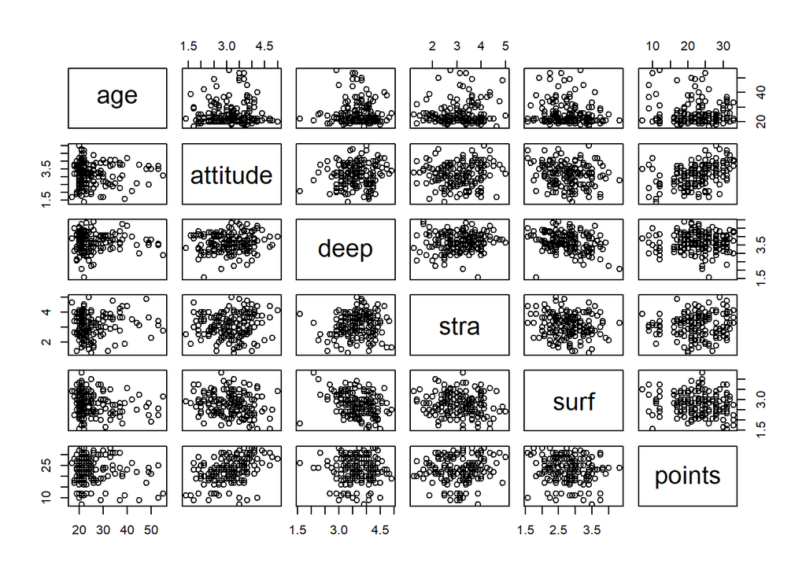

```r
# Here, we try to show the graphical overview of the data using pairs excluding the first variable
pairs(learning2014[-1])
```

Figure 2.

Notice that we repeated the ploting of the variables in learning2014 data by using the pairs function and excluding “gender”.

*interpretations:*

Figure 2 presents the selected variables in diagonal. each row displays a variable on the y-axis and the other variables on the corresponding x- axis. For example, the first row “age” is displayed on the y-axis whereas attitude, deep, stra, and surf are displayed on the x-axis for each of the 5 plots on that row.

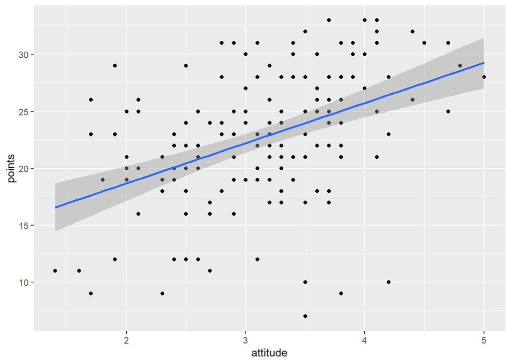

```r
# Here we are using three variables to fit our regression model. The variables are attitude, and points, where points is out dependent variable.

library(ggplot2)
qplot(attitude, points, data = learning2014) + geom_smooth(method = "lm")
```

```r
# Here we try to fit our a linear model. The dependent variable is points while the explanatory variable is attitude
model <- lm(points ~ attitude, data = learning2014)

# Now let us print the summary of our model
summary(model)
```

```
##
## Call:
## lm(formula = points ~ attitude, data = learning2014)
##
## Residuals:
##      Min       1Q   Median       3Q      Max
## -16.9763  -3.2119   0.4339   4.1534  10.6645
##
## Coefficients:
##             Estimate Std. Error t value Pr(>|t|)
## (Intercept)  11.6372     1.8303   6.358 1.95e-09 ***
## attitude      3.5255     0.5674   6.214 4.12e-09 ***
## ---
## Signif. codes:  0 '***' 0.001 '**' 0.01 '*' 0.05 '.' 0.1 ' ' 1
##
## Residual standard error: 5.32 on 164 degrees of freedom
## Multiple R-squared:  0.1906, Adjusted R-squared:  0.1856
## F-statistic: 38.61 on 1 and 164 DF,  p-value: 4.119e-09
```

*Explanation of the model summary*

In our linear regression model y=α+βx+ϵ, the dependent variable y is “points”, and the explanatory variable x is “attitude”.

We computed the summary of the model by calling the lm function lm(formula = points ~ attitude, data = learning2014)

### Let us fit the model with other explanatory variables (deep, stra, and surf) to see their estimated effect on the dependant variable (points)

```r
# Here we try to fit another linear model. The dependent variable is points while the explanatory variable is deep
model <- lm(points ~ deep, data = learning2014)

# Now let us print the summary of our model
summary(model)
```

```
##
## Call:
## lm(formula = points ~ deep, data = learning2014)
##
## Residuals:
##      Min       1Q   Median       3Q      Max
## -15.6913  -3.6935   0.2862   4.9957  10.3537
##
## Coefficients:
##             Estimate Std. Error t value Pr(>|t|)
## (Intercept)  23.1141     3.0908   7.478 4.31e-12 ***
## deep         -0.1080     0.8306  -0.130    0.897
## ---
## Signif. codes:  0 '***' 0.001 '**' 0.01 '*' 0.05 '.' 0.1 ' ' 1
##
## Residual standard error: 5.913 on 164 degrees of freedom
## Multiple R-squared:  0.000103,   Adjusted R-squared:  -0.005994
## F-statistic: 0.01689 on 1 and 164 DF,  p-value: 0.8967
```

The summary of this model did not show a significant relationships betwwen deep and points

```r
# Here we try to fit another linear model. The dependent variable is points while the explanatory variable is stra
model <- lm(points ~ stra, data = learning2014)

# Now let us print the summary of our model
summary(model)
```

```
##
## Call:
## lm(formula = points ~ stra, data = learning2014)
##
## Residuals:
##      Min       1Q   Median       3Q      Max
## -16.5581  -3.8198   0.1042   4.3024  10.1394
##
## Coefficients:
##             Estimate Std. Error t value Pr(>|t|)
## (Intercept)   19.233      1.897  10.141   <2e-16 ***
## stra           1.116      0.590   1.892   0.0603 .
## ---
## Signif. codes:  0 '***' 0.001 '**' 0.01 '*' 0.05 '.' 0.1 ' ' 1
##
## Residual standard error: 5.849 on 164 degrees of freedom
## Multiple R-squared:  0.02135,    Adjusted R-squared:  0.01538
## F-statistic: 3.578 on 1 and 164 DF,  p-value: 0.06031
```

No Significance between stra and points

```r
# Here we try to fit another linear model. The dependent variable is points while the explanatory variable is surf
model <- lm(points ~ surf, data = learning2014)

# Now let us print the summary of our model
summary(model)
```

```
##
## Call:
## lm(formula = points ~ surf, data = learning2014)
##
## Residuals:
##      Min       1Q   Median       3Q      Max
## -14.6539  -3.3744   0.3574   4.4734  10.2234
##
## Coefficients:
##             Estimate Std. Error t value Pr(>|t|)
## (Intercept)  27.2017     2.4432  11.134   <2e-16 ***
## surf         -1.6091     0.8613  -1.868   0.0635 .
## ---
## Signif. codes:  0 '***' 0.001 '**' 0.01 '*' 0.05 '.' 0.1 ' ' 1
##
## Residual standard error: 5.851 on 164 degrees of freedom
## Multiple R-squared:  0.02084,    Adjusted R-squared:  0.01487
## F-statistic:  3.49 on 1 and 164 DF,  p-value: 0.06351
```

No significance effect of surf on points

## Multiple regression

Multiple regression is conducted when there are more than one explanatory variables in a model. The above situation where each variable was fitted into the simple linear regression to estimate their individual effect on the dependent variable can be made analysis can be simplified by conducting a multiple regression analysis

```r
# We would like to run a multiple regression with this code
model2 <- lm(points ~ attitude + stra + surf, data = learning2014)

# Let us print the summary of our multiple regression
summary(model2)
```

```
##
## Call:
## lm(formula = points ~ attitude + stra + surf, data = learning2014)
##
## Residuals:
##      Min       1Q   Median       3Q      Max
## -17.1550  -3.4346   0.5156   3.6401  10.8952
##
## Coefficients:
##             Estimate Std. Error t value Pr(>|t|)
## (Intercept)  11.0171     3.6837   2.991  0.00322 **
## attitude      3.3952     0.5741   5.913 1.93e-08 ***
## stra          0.8531     0.5416   1.575  0.11716
## surf         -0.5861     0.8014  -0.731  0.46563
## ---
## Signif. codes:  0 '***' 0.001 '**' 0.01 '*' 0.05 '.' 0.1 ' ' 1
##
## Residual standard error: 5.296 on 162 degrees of freedom
## Multiple R-squared:  0.2074, Adjusted R-squared:  0.1927
## F-statistic: 14.13 on 3 and 162 DF,  p-value: 3.156e-08
```

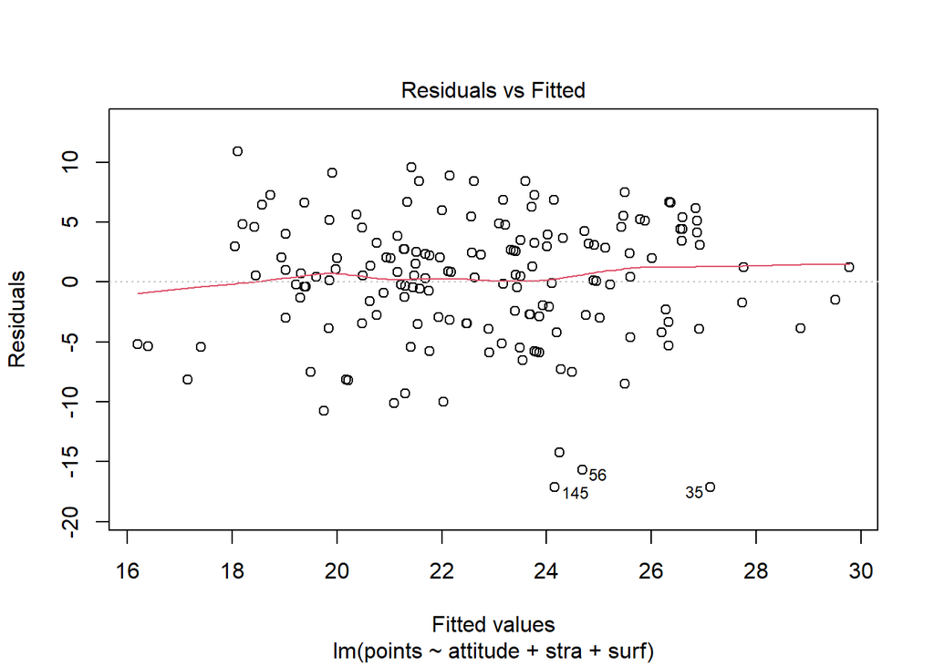

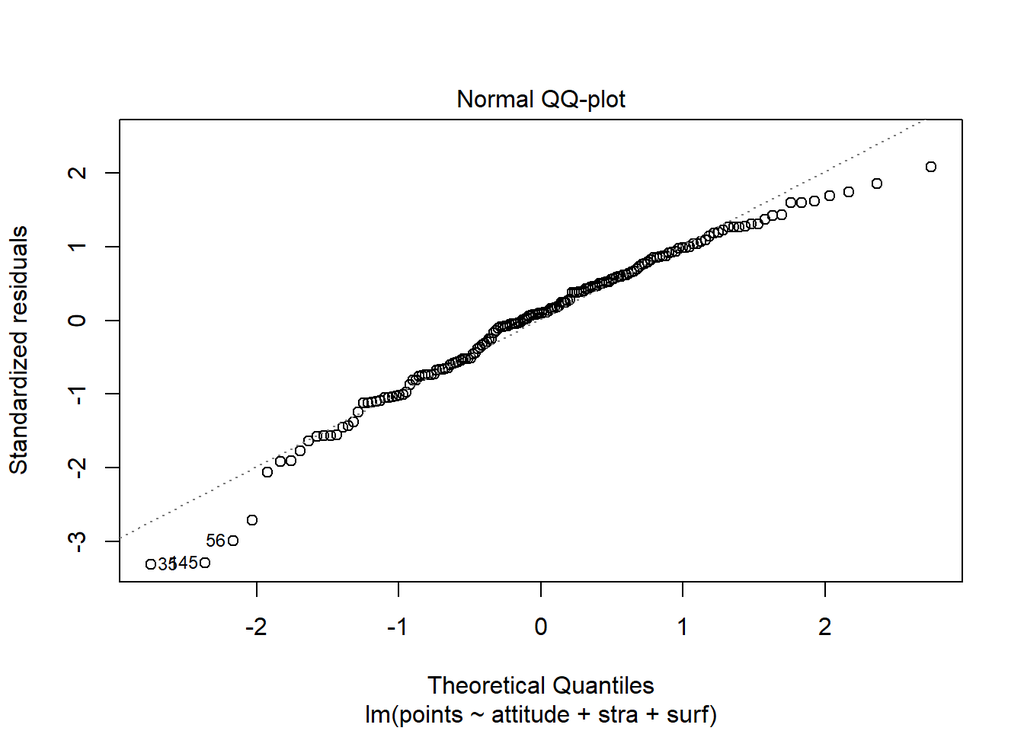

[figure not shown]

```r
# Here we want to draw the diagnostic plots using the plot() function.
plot(model2, which = c(1,2,3), caption = list("Residuals vs Fitted", "Normal QQ-plot", "Residuals vs Leverage"))
```

#### Explanation of the diagnostic plots

1. For the QQ plot, the normality assumption shows reasonable fit to the line implying that the errors of the model are normally distributed.

2.For the Residual VS Fitted plot shows that as the fitted values increases, the scattered plot deviates from the line.